# post1

Rongyun Tang

December 11, 2018

## Census income

research outlines:

1. Objective:task is to determine what kind of a person makes over 50K a year based on census data.
2. Method: statistics and association rules
3. Data Source: this “Adult” dataset was downloaded from UCI Machine Learning website: http://archive.ics.uci.edu/ml/datasets/Adult. It is multivariated dataset(including categorical and Integer variables) from social area. A set of reasonably clean records was extracted by the data dornors.It is also splited into train-test using MLC++ GenCVFiles (2/3, 1/3 random).

=======================================================================================================

Attribute Information:

======================================================================================================= Listing of attributes: salaries are potentially divided into two classes: >50K, <=50K.

age: continuous. workclass: Private, Self-emp-not-inc, Self-emp-inc, Federal-gov, Local-gov, State-gov, Without-pay, Never-worked. fnlwgt: continuous. education: Bachelors, Some-college, 11th, HS-grad, Prof-school, Assoc-acdm, Assoc-voc, 9th, 7th-8th, 12th, Masters, 1st-4th, 10th, Doctorate, 5th-6th, Preschool. education-num: continuous. marital-status: Married-civ-spouse, Divorced, Never-married, Separated, Widowed, Married-spouse-absent, Married-AF-spouse. occupation: Tech-support, Craft-repair, Other-service, Sales, Exec-managerial, Prof-specialty, Handlers-cleaners, Machine-op-inspct, Adm-clerical, Farming-fishing, Transport-moving, Priv-house-serv, Protective-serv, Armed-Forces. relationship: Wife, Own-child, Husband, Not-in-family, Other-relative, Unmarried. race: White, Asian-Pac-Islander, Amer-Indian-Eskimo, Other, Black. sex: Female, Male. capital-gain: continuous. capital-loss: continuous. hours-per-week: continuous. native-country: United-States, Cambodia, England, Puerto-Rico, Canada, Germany, Outlying-US(Guam-USVI-etc), India, Japan, Greece, South, China, Cuba, Iran, Honduras, Philippines, Italy, Poland, Jamaica, Vietnam, Mexico, Portugal, Ireland, France, Dominican-Republic, Laos, Ecuador, Taiwan, Haiti, Columbia, Hungary, Guatemala, Nicaragua, Scotland, Thailand, Yugoslavia, El-Salvador, Trinadad&Tobago, Peru, Hong, Holand-Netherlands.

```r
## 1. Data preprocessing
training.data <- as.data.frame(read.csv('adult.data'))
test.data <- as.data.frame(read.csv('adult.test', skip=1))
content <- readLines('old.adult.names')

i <- grep("Attribute Information",content) + 2
  var.names <- NULL
  while(content[i]!="") {
    j <- gregexpr(":", content[i])[[1]][1]
    var.names <- c(var.names, substr(content[i],1,j-1))
    i <- i + 1
  }
  names(training.data) <- gsub("-","",var.names)
  names(test.data) <- gsub("-","",var.names)
  N.obs <- dim(training.data)[1]
  N.var <- dim(training.data)[2]

  # show some data information:
  print("Traning data examples: ")
```

```
## [1] "Traning data examples: "
```

```r
  head(training.data)
```

```
##   age         workclass fnlwgt  education educationnum
## 1  50  Self-emp-not-inc  83311  Bachelors           13
## 2  38           Private 215646    HS-grad            9
## 3  53           Private 234721       11th            7
## 4  28           Private 338409  Bachelors           13
## 5  37           Private 284582    Masters           14
## 6  49           Private 160187        9th            5
##            maritalstatus         occupation   relationship   race     sex
## 1     Married-civ-spouse    Exec-managerial        Husband  White    Male
## 2               Divorced  Handlers-cleaners  Not-in-family  White    Male
## 3     Married-civ-spouse  Handlers-cleaners        Husband  Black    Male
## 4     Married-civ-spouse     Prof-specialty           Wife  Black  Female
## 5     Married-civ-spouse    Exec-managerial           Wife  White  Female
## 6  Married-spouse-absent      Other-service  Not-in-family  Black  Female
##   capitalgain capitalloss hoursperweek  nativecountry  class
## 1           0           0           13  United-States  <=50K
## 2           0           0           40  United-States  <=50K
## 3           0           0           40  United-States  <=50K
## 4           0           0           40           Cuba  <=50K
## 5           0           0           40  United-States  <=50K
## 6           0           0           16        Jamaica  <=50K
```

```r
  cat("Number of observations:",N.obs,"

     Number of variables:",N.var,"\n")
```

```
## Number of observations: 32560
##
##      Number of variables: 15
```

```r
#install.packages('VIM')
library("VIM")
# missing values detection
print("This is for missing values detection:")
```

```
## [1] "This is for missing values detection:"
```

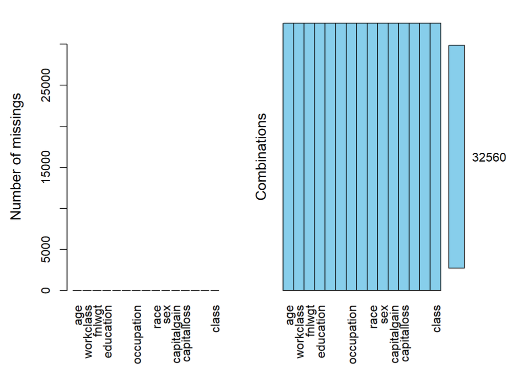

```r
aggr(training.data,prop=FALSE,numbers=TRUE)
```

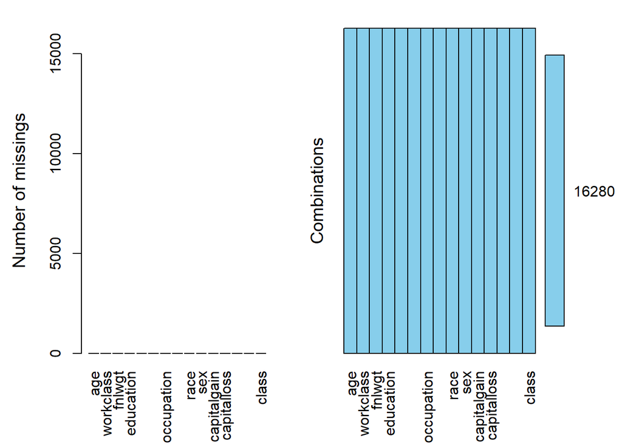

```r
aggr(test.data,prop=FALSE,numbers=TRUE)
```

```r
print("Numbers of missing values in trainning data and test dat: 0 , 0 ")
```

```
## [1] "Numbers of missing values in trainning data and test dat: 0 , 0 "
```

```r
# since most of the variables are categorial, so we didn't do outliers detection here
```

## 2. statistics on numerical variables

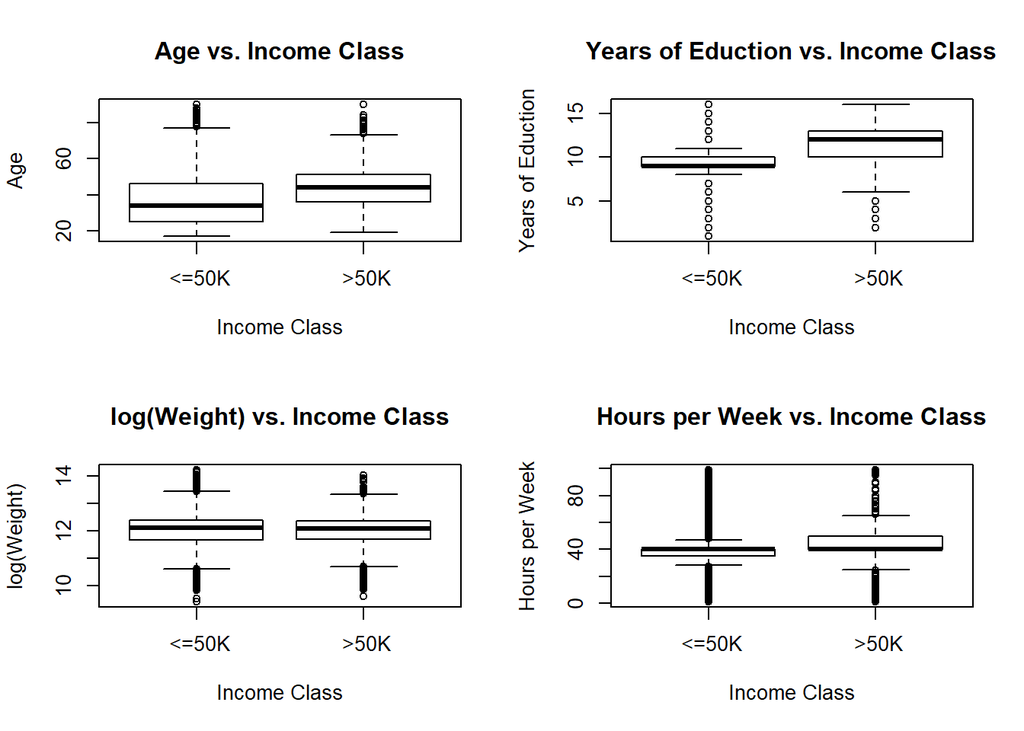

```r
par(mfrow=c(2,2))  ## Arrange plots in a 4x4 grid
boxplot(training.data[,'age']~training.data[,'class'], main="Age vs. Income Class",
        xlab="Income Class", ylab="Age")
boxplot(training.data[,'educationnum']~training.data[,'class'], main="Years of Eduction vs. Income Class",
        xlab="Income Class", ylab="Years of Eduction")
boxplot(log(training.data[,'fnlwgt'])~training.data[,'class'], main="log(Weight) vs. Income Class",
        xlab="Income Class", ylab="log(Weight)")
boxplot(training.data[,'hoursperweek']~training.data[,'class'], main="Hours per Week vs. Income Class",
        xlab="Income Class", ylab="Hours per Week")
```

```r
par(mfrow=c(1,1))
```

numerical data distribution analysis:

1. In group that income >50k, people are more likely to have higher average age, higher average education years and higher weekly work hours than whose income is <=50K.
2. Weight shows no difference in these two classes.

## 3. association rules of categorial variables

```r
library(arules)
training<-training.data[,c(2,4,6:10,14,15)]
summary(training)
```

```
##              workclass             education
##   Private         :22696    HS-grad     :10501
##   Self-emp-not-inc: 2541    Some-college: 7291
##   Local-gov       : 2093    Bachelors   : 5354
##   ?               : 1836    Masters     : 1723
##   State-gov       : 1297    Assoc-voc   : 1382
##   Self-emp-inc    : 1116    11th        : 1175
##  (Other)          :  981   (Other)      : 5134
##                 maritalstatus              occupation
##   Divorced             : 4443    Prof-specialty :4140
##   Married-AF-spouse    :   23    Craft-repair   :4099
##   Married-civ-spouse   :14976    Exec-managerial:4066
##   Married-spouse-absent:  418    Adm-clerical   :3769
##   Never-married        :10682    Sales          :3650
##   Separated            : 1025    Other-service  :3295
##   Widowed              :  993   (Other)         :9541
##           relationship                    race            sex
##   Husband       :13193    Amer-Indian-Eskimo:  311    Female:10771
##   Not-in-family : 8304    Asian-Pac-Islander: 1039    Male  :21789
##   Other-relative:  981    Black             : 3124
##   Own-child     : 5068    Other             :  271
##   Unmarried     : 3446    White             :27815
##   Wife          : 1568
##
##         nativecountry      class
##   United-States:29169    <=50K:24719
##   Mexico       :  643    >50K : 7841
##   ?            :  583
##   Philippines  :  198
##   Germany      :  137
##   Canada       :  121
##  (Other)       : 1709
```

```r
# use apriori rules to find association rules on people whose income class is >50K
rules <- apriori(training,
                 control = list(verbose=F),
                 parameter = list(minlen=2, supp=0.005, conf=0.8),
                 appearance = list(rhs=c("class= >50K"),
                                   default="lhs"))

inspect(sort(rules, by="lift", decreasing = TRUE)[1:5])
```

```
##     lhs                                    rhs              support confidence     lift count
## [1] {workclass= Private,
##      education= Masters,
##      occupation= Exec-managerial,
##      relationship= Husband,
##      nativecountry= United-States}      => {class= >50K} 0.00509828  0.9273743 3.850951   166
## [2] {workclass= Private,
##      education= Masters,
##      maritalstatus= Married-civ-spouse,
##      occupation= Exec-managerial,
##      relationship= Husband,
##      nativecountry= United-States}      => {class= >50K} 0.00509828  0.9273743 3.850951   166
## [3] {workclass= Private,
##      education= Masters,
##      occupation= Exec-managerial,
##      relationship= Husband,
##      sex= Male,
##      nativecountry= United-States}      => {class= >50K} 0.00509828  0.9273743 3.850951   166
## [4] {workclass= Private,
##      education= Masters,
##      maritalstatus= Married-civ-spouse,
##      occupation= Exec-managerial,
##      sex= Male,
##      nativecountry= United-States}      => {class= >50K} 0.00509828  0.9273743 3.850951   166
## [5] {workclass= Private,
##      education= Masters,
##      maritalstatus= Married-civ-spouse,
##      occupation= Exec-managerial,
##      relationship= Husband,
##      sex= Male,
##      nativecountry= United-States}      => {class= >50K} 0.00509828  0.9273743 3.850951   166
```

## 4. association rules validation

```r
# using test data and comfusion matrix to test the results
test<-test.data[,c(2,4,6:10,14,15)]
summary(test)
```

```
##              workclass             education
##   Private         :11209    HS-grad     :5283
##   Self-emp-not-inc: 1321    Some-college:3587
##   Local-gov       : 1043    Bachelors   :2670
##   ?               :  963    Masters     : 934
##   State-gov       :  683    Assoc-voc   : 679
##   Self-emp-inc    :  579    11th        : 636
##  (Other)          :  482   (Other)      :2491
##                 maritalstatus             occupation
##   Divorced             :2190    Prof-specialty :2032
##   Married-AF-spouse    :  14    Exec-managerial:2020
##   Married-civ-spouse   :7403    Craft-repair   :2013
##   Married-spouse-absent: 210    Sales          :1854
##   Never-married        :5433    Adm-clerical   :1841
##   Separated            : 505    Other-service  :1628
##   Widowed              : 525   (Other)         :4892
##           relationship                   race            sex
##   Husband       :6523    Amer-Indian-Eskimo:  159    Female: 5421
##   Not-in-family :4278    Asian-Pac-Islander:  480    Male  :10859
##   Other-relative: 525    Black             : 1560
##   Own-child     :2512    Other             :  135
##   Unmarried     :1679    White             :13946
##   Wife          : 763
##
##         nativecountry       class
##   United-States:14661    <=50K.:12434
##   Mexico       :  308    >50K. : 3846
##   ?            :  274
##   Philippines  :   97
##   Puerto-Rico  :   70
##   Germany      :   69
##  (Other)       :  801
```

```r
test.rule1<-subset(test, (workclass==' Private') & (education==' Masters') & (occupation==' Exec-managerial') & (relationship==' Husband') & (nativecountry==' United-States'))
accuracy.rules1=nrow(subset(test.rule1,class==' >50K.'))/nrow(test.rule1)

test.rule2<-subset(test,workclass==' Private' & education==' Masters' & maritalstatus==' Married-civ-spouse' & occupation==' Exec-managerial' & relationship==' Husband' & nativecountry==' United-States')
accuracy.rules2=nrow(subset(test.rule2,class==' >50K.'))/nrow(test.rule2)

test.rule3<-subset(test,workclass==' Private' & education==' Masters' & occupation==' Exec-managerial' & relationship==' Husband' & sex==' Male')
accuracy.rules3=nrow(subset(test.rule3,class==' >50K.'))/nrow(test.rule3)


test.rule4<-subset(test,workclass==' Private' & education==' Masters' & maritalstatus==' Married-civ-spouse' & occupation==' Exec-managerial' & sex==' Male' & nativecountry==' United-States')
accuracy.rules4=nrow(subset(test.rule4,class==' >50K.'))/nrow(test.rule4)


test.rule5<-subset(test,workclass==' Private' & education==' Masters' & maritalstatus==' Married-civ-spouse' & occupation==' Exec-managerial' & relationship==' Husband' & sex==' Male' & nativecountry==' United-States')
accuracy.rules5=nrow(subset(test.rule5,class==' >50K.'))/nrow(test.rule5)

paste('accuracy of association rule1,rule2,rule3,rule4 and rule5 are:',round(accuracy.rules1,3),round(accuracy.rules2,3),round(accuracy.rules3,3), round(accuracy.rules4,3), round(accuracy.rules5,3))
```

```
## [1] "accuracy of association rule1,rule2,rule3,rule4 and rule5 are: 0.909 0.909 0.885 0.909 0.909"
```

## 5. conclusions

1. numerical statistic analysis showed that people have higher average age, higher average education years and higher weekly work hours are more likely to have income >50K.
2. association rules listed in this project showed good accuracies: rule1(91%),rule2(91%),rule3(89%),rule4(91%),rule5(91%).
3. association rules showed that people who have master degrees, work privately married male with an Exec-managerial occupation have large possibilities(>80%) to have salaries more than 50,000.